# Analysis of T$_{\text{RM}}$ population dynamics

This approach illustrates how a simple mathematical model can be applied to experimental data of T$_{\text{RM}}$ in nonlymphoid tissues. The aim is to estimate the clonal half-life of each population and project dynamics beyond experimental timeframes.

### Modeling approach

A simple model of homeostasis assumes new T$_{\text{RM}}$ cells ($T$) are recruited from a precursor subset at rate $r$, proliferate at rate $p$, and decay at rate $d$. These dynamics be expressed mathematically as

$$\begin{align}
\frac{dT}{dt} &= r + p T - d T\nonumber \\
& = r - (d - p)T,
\end{align}$$

where $d-p$ is the net loss rate from the population. If there is no recruitment from precursor populations, then $r=0$ and Eqn 1 can be solved to give

$$\begin{align}
T = T^0 \exp^{- (d-p)t},
\end{align}$$

where $T^0$ is the initial number of T$_{\text{RM}}$. Thus, assuming cells are lost at a faster rate than they divide (i.e. $d > p$), the clonal population will decline exponentially at rate $(d-p)$, with an average half-life of $\log(2)/(d-p)$.

T$_{\text{RM}}$ loss can be modeled by log-transforming Eq 2 to obtain a linear regression model with intercept $\log(T^0)$ and slope $-(d-p)$, i.e.

$$\begin{align}
\log(T) = \log(T^0) - (d-p)t.
\end{align}$$

Using least squares optimization, we fit Eq 3 to the log-transformed measurements from each dataset and estimate the corresponding net loss rate and clonal half-life. For more details on motivation for the model, see Morris et al (2019) Journal of Immunology. Details of the data can be found in:

- Pizzolla et al (2017) Science Immunology, doi:10.1126/sciimmunol.aam6970
- Slutter et al (2017) Science Immunology, doi:10.1126/sciimmunol.aag2031

Note that in a more thorough analysis, these predictions would be compared with alternative models to assess the most parsimonious description of the data.

### Analysis

To implement the analysis in R, we use the following steps.

1. Load the required packages:

```r
require(tidyverse)
require(cowplot)
```

2. Define settings for the final plot:

```r
basetext <- 10
mytheme <- ggthemes::theme_tufte(base_family = "Helvetica") +
    theme(axis.text = element_text(size = basetext),
          axis.title = element_text(size = basetext + 0.5),
          legend.text = element_text(size = basetext),
          legend.title = element_text(size = basetext + 0.5),
          strip.text.x = element_text(size = basetext + 0.5),
          panel.border = element_rect(colour = "black", fill = NA))

ybreaks <- c(1e0, 1e2, 1e4, 1e6)
ylabels <- expression(1, 10^2, 10^4, 10^6)
ytitle <- expression(CD69^{"+"}~CD103^{"+"}~T[RM])

textsize <- 10
```

3. Define functions that will be used in the analysis. Note that for the response variable we use the approximation $\log$(T$_{\text{RM}} + 1$) to avoid NAs when T$_{\text{RM}} = 0$. This does not substantially impact our results, and is preferable to omitting important information contained in those undetectable measurements.

```r
# 1. Estimate parameters and 95% CIs by fitting linear model

getparams <- function(data){
    lmfit <- lm(log(Trm + 1) ~ day, data = data)

    netloss <- - coef(lmfit)[2]

    return( data.frame(netloss = netloss, halflife = log(2)/netloss) )
}

# 2 Test for normal residuals from fitted linear model
testresids <- function(data){
    lmfit <- lm(log(Trm + 1) ~ day, data = data)

    pval <- shapiro.test(lmfit$residuals)$p.value

    return(data.frame(pval = pval) )
}

# 3. Get predictions from fitted linear model
getpredictions <- function(data, xnew){
    lmfit <- lm(log(Trm + 1) ~ day, data = data)

    predictions <- data.frame(day = xnew, Trm = predict(lmfit, xnew, interval = "confidence")) %>%
        mutate(Trm = exp(Trm.fit) - 1, upper = exp(Trm.upr) - 1, lower = exp(Trm.lwr) - 1)

    return(predictions)
}
```

4. Load the data:

```r
load("data_pizzolla.RData")
load("data_slutter.RData")
```

5. Carry out analysis for each data set:

```r
## Pizzolla et al analysis ----------------------------------

# 1. Model fitting
params_pizzolla <- data_pizzolla %>% group_by(tissue, study) %>% do(getparams(data = .) )

resids_pizzolla <- data_pizzolla %>% group_by(tissue, study) %>% do(testresids(data = .) )

# 2. Model predictions
xnew <- data.frame(day = seq(0, 250, by = 0.5))

predict_pizzolla <- data_pizzolla %>% group_by(tissue, study) %>%
    do(getpredictions(data = ., xnew = xnew) ) %>% ungroup()
```

```r
## Slutter et al analysis ----------------------------------

# 1. Model fitting
params_slutter <- data_slutter %>% group_by(tissue, study) %>% do(getparams(data = .) )

resids_slutter <- data_slutter %>% group_by(tissue, study) %>% do(testresids(data = .) )

# 2. Model predictions
predict_slutter <- data_slutter %>% group_by(tissue, study) %>%
    do(getpredictions(data = ., xnew = xnew) ) %>% ungroup()
```

6. Plot the results:

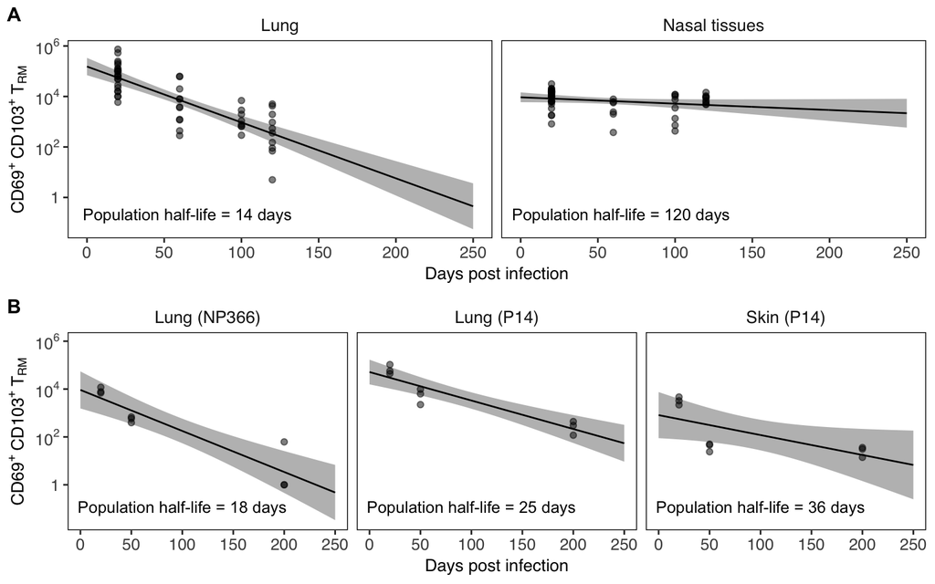

```r
plot_pizzolla <- ggplot(data = data_pizzolla, aes(x = day, y = Trm + 1)) +
    facet_wrap(~ tissue) +
    geom_ribbon(data = predict_pizzolla, aes(x = day, ymin = lower + 1, ymax = upper + 1),
                fill = "grey") +
    geom_line(data = predict_pizzolla) + geom_point(alpha = 0.5) +
    geom_text(data = params_pizzolla,
              aes(x = 65, y = 2.2e-1,
                  label = paste("Population half-life =", signif(halflife, 2), "days")),
              size = textsize/.pt) +
    mytheme + scale_x_continuous("Days post infection") +
    scale_y_continuous(ytitle, breaks = ybreaks, labels = ylabels, trans = "log")

plot_slutter <- ggplot(data = data_slutter, aes(x = day, y = Trm + 1)) +
    facet_wrap(~ tissue) +
    geom_ribbon(data = predict_slutter, aes(x = day, ymin = lower + 1, ymax = upper + 1),
                fill = "grey") +
    geom_line(data = predict_slutter) + geom_point(alpha = 0.5) +
    geom_text(data = params_slutter,
              aes(x = 100, y = 1.2e-1,
                  label = paste("Population half-life =", signif(halflife, 2), "days")),
              size = textsize/.pt) +
    mytheme + scale_x_continuous("Days post infection") +
    scale_y_continuous(ytitle, breaks = ybreaks, labels = ylabels,
                       limits = c(3e-2, 1e6), trans = "log")

print(
    plot_all <- plot_grid(plot_pizzolla, plot_slutter,
                          nrow = 2, labels = c("A", "B"), label_size = 12)
)
```

7. Finally, to estimate the time at which OT-I (Panel A) and NP366 (Panel B) T$_{\text{RM}}$ in the lung become undetectable, we simply find the first time at which their predicted population sizes fall below one:

```r
predict_pizzolla %>% filter(tissue == "Lung", Trm < 1) %>%
    slice(1) %>% mutate(day = signif(day, 2)) %>% select(day)
```

```
## # A tibble: 1 x 1
##     day
##   <dbl>
## 1   220
```

```r
predict_slutter %>% filter(tissue == "Lung (NP366)", Trm < 1) %>%
    slice(1)  %>% mutate(day = signif(day, 2)) %>% select(day)
```

```
## # A tibble: 1 x 1
##     day
##   <dbl>
## 1   210
```